# DASC 500: Introduction to Data Analytics

Statistical Inference (Part 2 - Applications)

Maj Jason Freels PhD

16 February 2020

# Overview

## In this presentation

- Estimation
  - Point estimators for the mean
  - Point estimators for the variance
  - Constructing confidence intervals
- Hypothesis tests
  - Two sided hypothesis test for the mean
  - One-sided hypothesis test for the mean

## Setup

- To follow along with this you’ll need to import the following libraries into your Python workspace (or Google Colab instance)

```python
import statistics as st
import numpy as np
import seaborn as sb
import matplotlib.pyplot as plt
import pandas as pd
import scipy as sp
```

# Point estimators for the mean (IID, Normally distributed)

## Overview

- The random sample is composed of observations $x_{1},\ldots,x_{n}$ drawn from $n$ independent random variables $X_1,\ldots,X_n$ each of which are normally distributed and having unknown mean $\mu$ and unknown variance $\sigma^2$
- In this scenario an estimator for the population mean $\mu$ is the sample mean

$$\bar{X}_n = \frac{1}{n}\sum_{i=1}^n X_i$$

## Properties of the estimator

- As shown below, the expected value of this estimator is equal to the population parameter $\mu$, therefore the estimator is unbiased

$$\begin{aligned}
\operatorname{E}[\bar{X}_n] &= \operatorname{E}\bigg[\frac{1}{n}\sum_{i=1}^n X_i\bigg]\\
&=\frac{1}{n}\sum_{i=1}^n \operatorname{E}[X_i]\\
&=\frac{1}{n}\sum_{i=1}^n \mu\\
&=\frac{1}{n}n \mu\\
&=\mu
\end{aligned}$$

- Our sequence of random variables (IID with finite mean) satisfies the conditions of [Kolmogorov’s Strong Law of Large Numbers](http://mathworld.wolfram.com/StrongLawofLargeNumbers.html)
- Therefore, the sample mean $\bar{X}_n$ converges [almost surely](https://math.stackexchange.com/questions/1443015/why-do-we-say-almost-surely-in-probability-theory) to the true mean $\mu$ and is strongly consistent
- Convergence of the the sample mean estimator to the population mean

```python
loc = 5.43
scl = 2.65

normal5       = np.random.normal(loc = loc, scale = scl, size = 5)
normal10      = np.random.normal(loc = loc, scale = scl, size = 10)
normal50      = np.random.normal(loc = loc, scale = scl, size = 50)
normal100     = np.random.normal(loc = loc, scale = scl, size = 100)
normal500     = np.random.normal(loc = loc, scale = scl, size = 500)
normal1000    = np.random.normal(loc = loc, scale = scl, size = 100)
normal5000    = np.random.normal(loc = loc, scale = scl, size = 5000)
normal10000   = np.random.normal(loc = loc, scale = scl, size = 10000)
normal50000   = np.random.normal(loc = loc, scale = scl, size = 50000)
normal100000  = np.random.normal(loc = loc, scale = scl, size = 100000)
normal500000  = np.random.normal(loc = loc, scale = scl, size = 500000)
normal1000000 = np.random.normal(loc = loc, scale = scl, size = 1000000)
```

```python
means = pd.DataFrame([st.mean(normal5),
                      st.mean(normal10),
                      st.mean(normal50),
                      st.mean(normal100),
                      st.mean(normal500),
                      st.mean(normal1000),
                      st.mean(normal5000),
                      st.mean(normal10000),
                      st.mean(normal50000),
                      st.mean(normal100000),
                      st.mean(normal500000),
                      st.mean(normal1000000)],
                      columns =  ["Mean"],
                      index = ["      5 obs = ",
                               "     10 obs = ",
                               "     50 obs = ",
                               "    100 obs = ",
                               "    500 obs = ",
                               "   1000 obs = ",
                               "   5000 obs = ",
                               "  10000 obs = ",
                               "  50000 obs = ",
                               " 100000 obs = ",
                               " 500000 obs = ",
                               "1000000 obs = "])
print(means)
```

```
                    Mean
      5 obs =   4.162024
     10 obs =   3.693037
     50 obs =   4.841587
    100 obs =   5.072030
    500 obs =   5.223584
   1000 obs =   5.371927
   5000 obs =   5.363139
  10000 obs =   5.406527
  50000 obs =   5.434392
 100000 obs =   5.431039
 500000 obs =   5.430067
1000000 obs =   5.430199
```

- The variance of the estimator $\bar{X}_n$ is equal to $\sigma^{2}/n$
- This can be shown by applying the variance operator and noting that the obervations are independent

$$\begin{aligned}
\operatorname{Var}[\bar{X}_n] &= \operatorname{Var}\bigg[\frac{1}{n}\sum_{i=1}^n X_i\bigg]\\
&=\frac{1}{n^2}\operatorname{Var}\bigg[\sum_{i=1}^n X_i\bigg]\\
&=\frac{1}{n^2}\sum_{i=1}^n \operatorname{Var}[X_i]\\
&=\frac{1}{n^2}\sum_{i=1}^n \sigma^2\\
&=\frac{1}{n^2}n \sigma^2\\
&=\frac{\sigma^2}{n}
\end{aligned}$$

- The variance of this estimator converges to zero as the sample size $n$ goes to infinity $\infty$

```python
Vars = pd.DataFrame([st.variance(normal5),
                     st.variance(normal10),
                     st.variance(normal50),
                     st.variance(normal100),
                     st.variance(normal500),
                     st.variance(normal1000),
                     st.variance(normal5000),
                     st.variance(normal10000),
                     st.variance(normal50000),
                     st.variance(normal100000),
                     st.variance(normal500000),
                     st.variance(normal1000000)],
                      columns =  ["Variance"],
                      index = ["      5 obs = ",
                               "     10 obs = ",
                               "     50 obs = ",
                               "    100 obs = ",
                               "    500 obs = ",
                               "   1000 obs = ",
                               "   5000 obs = ",
                               "  10000 obs = ",
                               "  50000 obs = ",
                               " 100000 obs = ",
                               " 500000 obs = ",
                               "1000000 obs = "])
print(Vars)
```

```
                Variance
      5 obs =   5.441689
     10 obs =   5.938673
     50 obs =   7.379285
    100 obs =   6.450243
    500 obs =   7.254238
   1000 obs =   6.380081
   5000 obs =   7.133370
  10000 obs =   7.054218
  50000 obs =   7.076407
 100000 obs =   7.020978
 500000 obs =   7.033482
1000000 obs =   7.027249
```

- Using the results obtained above for the expected value and the variance of the estimator, it can be shown that the distribution of the estimator is

$$\bar{X}_n \sim \operatorname{NOR}(\mu,\sigma^2/n)$$

# Point estimators for the mean - (IID, not normally distributed)

## Overview

- The sample $x_{1},\ldots, x_{n}$ is composed of realizations drawn from $n$ independent random variables $X_1,\ldots, X_n$, all having the same distribution with unknown mean $\mu$ and variance $\sigma^2$
- As was shown above for the case when the random variables are all normally distributed, the estimator of the population mean $\mu$ is the sample mean

$$\bar{X}_n = \frac{1}{n}\sum_{i=1}^n X_i$$

## Properties of the estimator

- The expected value and the the variance of the estimator are the same as what was shown above for the case when the random variables are all normally distributed
- However, the distribution of the estimator does not necessarily have a normal distribution
  - Depends upon the distribution of each random variable in the the sequence $X_1,\ldots, X_n$
  - However, $\bar{X}_n$ is asymptotically normal distributed (i.e., converges to a normal distribution as $n$ becomes large)
  - The sequence satisfies the conditions of [Lindeberg-Lévy Central Limit Theorem](https://www.statlect.com/asymptotic-theory/central-limit-theorem) (IID sequence with finite mean and variance)
- The code below demonstrate how $\bar{X}_n$ converges to a normal distribution ($\bar{X}_n \xrightarrow{d} \operatorname{NOR}(0,\sigma^2)$)
- There are two variables of interest
  - The size of the random sample (`samp_siz`) this value controls the degree to which the sequence converges to a $\operatorname{NOR}(0,\sigma^2)$ distribution
  - The number of simulations run (`num_sims`) this variable does not effect how the sequence converges to a $\operatorname{NOR}(0,\sigma^2)$, but more simulations give us a clearer picture
- You should paste the code below into your Python console (or Google Colab instance) to define the function `norm_converge()`

```python
def norm_converge(samp_siz, num_sims, exp = True, param = 0.3):

    mean_vec = np.empty([num_sims])

    for i in range(num_sims):

      if exp == True:
          samp = np.random.exponential(scale = param, size = samp_siz)
      else:
          samp = np.random.weibull(a = param, size = samp_siz)

      mean_vec[i] = st.mean(samp)

    plot = sb.kdeplot(mean_vec, shade=True);
    plt.show(plot)
```

- With the function defined run the code shown below to view the effect of changing the variables

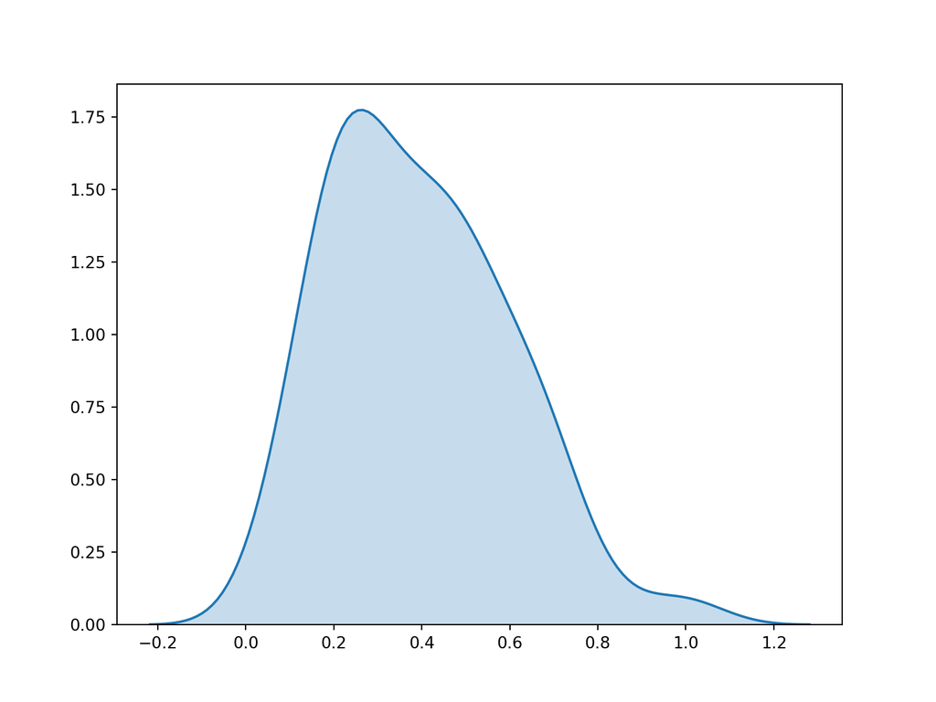

```python
norm_converge(samp_siz = 3, num_sims = 100, exp = True, param = 0.4)
```

# Point estimators for the variance (IID, Normally distributed, known mean)

## Overview

- The random sample $x_{1},\ldots,x_{n}$ is composed of realizations drawn from $n$ independent random variables $X_1,\ldots, X_n$, all of which are normally distributed with known mean $\mu$ and unknown variance $\sigma^2$
- Assuming that the variance is positive and finite $(0<\sigma^2<\infty)$, then by definition

$$\sigma^2=\operatorname{E}\Big[\big(X−\mu\big)^2\Big].$$

- Therefore, the variance is the mean of the random variable

$$Y = \big(X−\mu\big)^2.$$

- Which implies the following estimator for the variance, denoted by $S^2$

$$S^2 = \widehat{\sigma}^2 =\frac{1}{n}\sum_{i=1}^n\big(X_i−\mu\big)^2.$$

## Properties of the estimator

- Because of the linearity of the expectation operator it can be shown that $\overline{S}^2$ is an unbiased estimator of $\sigma^2$ if the value of the mean is known.
- However, We typically don’t know the value of $\mu$ - so we replace $\mu$ with its estimator, the sample mean, to obtain the following estimator for $\sigma^2$

$$S^2=\frac{1}{n}\sum_{i = 1}^n(X_i−\overline{X})^2$$

- After expanding the squared term and applying some algebra, we have the following estimator for the variance based on the sample mean

$$S^2=\frac{1}{n}\sum_{i = 1}^n(X^2_i−\overline{X}^2).$$

- We can determine whether this is an biased estimator for the variance as follows

$$\begin{aligned}
\operatorname{Bias}\big(S^2\big) &= \operatorname{E}\big[S^2\big]-\sigma^2\\
&=\frac{1}{n} \left(\sum_{i=1}^n E\big[X_i\big]^2-nE\big[\overline{X}^2\big]\right) - \sigma^2\\
&=\frac{1}{n} \left(n(\mu^2+\sigma^2)-n\left(\mu^2+\frac{\sigma^2}{n}\right)\right)-\sigma^2\\
&=\frac{n-1}{n}\sigma^2-\sigma^2\\
&=-\frac{\sigma^2}{n}
\end{aligned}$$

- Thus, we see that $\overline{S}^2$ is a biased estimator for the variance because it includes the $(n-1)/n$ term
- We can eliminate this term by multiplying $S^2$ by the reciprocal of this term $n/(n-1)$
- We know that including this term will cancel out the $(n-1)/n$ term in the end
- The result is an estimator known as adjusted sample variance $s^2$ which is an unbiased estimator for the variance

$$s^2=\frac{1}{n-1}\sum_{i = 1}^n(X_i−\overline{X})^2.$$

- The variance of the adjusted sample variance is expressed as shown below

$$\operatorname{Var}\left[s^2\right] = \frac{2\sigma^2}{n-1}$$

- While not done here, it can be shown that this estimator has a gamma distribution with parameters $n$, and $\sigma^2$

# Constructing confidence intervals

## Overview

- Let $X_1, X_2, X_3,\ldots, X_n$ be a random sample from a distribution with a parameter $\theta$ that is to be estimated
- An interval estimator with confidence level $1−\alpha$ consists of two estimators
  - A low estimator $\hat{\Theta}_l=\hat{\Theta}_l(X_1, X_2, \cdots, X_n)$
  - A high estimator $\hat{\Theta}_h=\hat{\Theta}_h(X_1, X_2, \cdots, X_n)$
- Such that for every possible value of $\theta$

$$P\bigg(\hat{\Theta}_l < \theta \, \textrm{and} \, \hat{\Theta}_h > \theta \bigg) \geq 0.95$$

## Finding Intervals Estimators

- Let $X$ be a continuous random variable with CDF $F_X(x)=P(X\leq x)$
- Suppose that we are interested in finding two values $x_h$ and $x_l$ such that

$$P\bigg(x_l \leq X \leq x_h \bigg)= 1-\alpha.$$

- One way to do this, is to find values of $x_l$ and $x_h$ for which

$$\begin{aligned}
P\big(X \leq x_l \big)= \frac{\alpha}{2}, \quad &\textrm{and} \quad P\big(X \geq x_h\big)= \frac{\alpha}{2}\\\\
&\text{or}\\\\
F_X(x_l)=\frac{\alpha}{2}, \quad &\textrm{and} \quad F_X(x_h)= 1-\frac{\alpha}{2}
\end{aligned}$$

- We can rewrite these equations by using the inverse CDF $F^{−1}_X$ as

$$x_l= F^{-1}_X\left(\frac{\alpha}{2}\right), \quad \textrm{and} \quad x_h= F^{-1}_X\left(1-\frac{\alpha}{2}\right).$$

- We call the interval $[x_l,x_h]$ a $(1−\alpha)$ interval for $X$
- A general approach is to start with a point estimator $\hat{\theta}$ and create the interval $\left[\hat{\theta}_l,\hat{\theta}_h\right]$ around it such that $P\bigg(\theta \in \big[\hat{\Theta}_l,\hat{\Theta}_h\big] \bigg) \geq 1-\alpha$

### Confidence interval for $\mu$ - Normally distributed sample

- Let $X_1, X_2, X_3,\ldots, X_n$ be a random sample from a normal distribution $NOR(\theta,1)$ - find a $95\%$ confidence interval for $\theta$

```python
# Number observations
N = 100

# choose level alpha
alpha = 0.05

# parameters
loc = 5.42
scl = 1

# Generate random samples
obs = np.random.normal(loc = loc, scale = scl, size = N)
```

- Start with $\hat{\theta}$, the point estimator for $\theta$
- Since $\theta$ is the mean of the distribution, the point estimator we start with is the sample mean

$$\hat{\theta}=\overline{X}_n=\frac{X_1+X_2+...+X_n}{n}.$$

- Since $X_i \sim NOR(\theta,1)$ and the $X_i$’s are independent, we conclude that

$$\overline{X}_n \sim N\left(\theta, \frac{1}{n}\right).$$

- By normalizing $\bar{X}_n$, we arrive at that the following random variable having a $NOR(0,1)$ distribution

$$\frac{\overline{X}_n-\theta}{\frac{1}{\sqrt{n}}}=\sqrt{n}(\overline{X}_n-\theta)$$

- Thus, for a $100(1-\alpha\%)$ confidence interval we have

$$P\bigg(-z_{(1-\alpha/2)} \leq \sqrt{n}(\overline{X}_n-\theta) \leq z_{(1-\alpha/2)} \bigg)=1-\alpha$$

- By rearranging the terms we have

$$P\bigg(\overline{X}_n-\frac{z_{(1-\alpha/2)}}{\sqrt{n}}\; \leq \;\theta\; \leq \; \overline{X}_n+\frac{z_{(1-\alpha/2)}}{\sqrt{n}}\bigg)=1-\alpha$$

- Therefore, the $100(1-\alpha)\%$ confidence interval for $\theta$ interval is

$$[\hat{\theta}_l, \hat{\theta}_h] =\left[\overline{X}_n-\frac{z_{(1-\alpha/2)}}{\sqrt{n}}, \overline{X}_n+\frac{z_{(1-\alpha/2)}}{\sqrt{n}}\right]$$

```python
# import the normal module from scipy
from scipy.stats import norm

# Find z value at alpha / 2
z = norm.ppf(1-alpha / 2, loc = 0, scale = 1)

theta_l, theta_h = st.mean(obs) - z / np.sqrt(N) , st.mean(obs) + z / np.sqrt(N)

theta_l, theta_h
```

```
(5.216350464915749, 5.608343261823759)
```

# Confidence Intervals for the Variance of Normal Random Variables

## Pivotal quantities

- The crucial fact about the previous example is the random variable $Q = \sqrt{n}(\bar{X}−\theta)$
- The random variable $Q$ is known as a pivotal quantity or simply a pivot
  - A pivot is a function of the observed data $X_1, X_2, X_3, \ldots, X_n$ and the unknown parameter $\theta$, but it does not depend on any other unknown parameters
  - The distribution of $Q$ does not depend on $\theta$ or any other unknown parameters
- To construct a confidence interval one is required to first find a pivotal quantity and its distribution

## Confidence interval for $\sigma^2$

- Suppose that we observe a random sample $X_1, X_2, X_3,\ldots, X_n$
- Further suppose that the observations in teh sample follow a normal distribution for which the mean $\mu$ and the variance $\sigma^2$ are both unknown
- Using the sample we are tasked with constructing an interval estimator for the variance $\sigma^2$
- In this scenario our pivotal quantity is

$$Q=\frac{(n-1)S^2}{\sigma^2}=\frac{1}{\sigma^2}\sum_{i=1}^{n} (X_i-\overline{X})^2$$

- This is a pivotal quantity because $Q$ is a function of the data and of the unknown parameter $\sigma$, but is not a function of the unknown mean $\mu$
- It can be shown that $Q$ follows a [chi-square distribution](https://stattrek.com/probability-distributions/chi-square.aspx) with $n-1$ degrees of freedom
- Thus a $100(1-\alpha\%)$ confidence interval can be constructed as

$$\begin{aligned}
P\left(\chi^2_{1-\frac{\alpha}{2},n-1} \leq Q \leq \chi^2_{\frac{\alpha}{2},n-1} \right)&= 1-\alpha\\\\
P\left(\chi^2_{1-\frac{\alpha}{2},n-1} \leq \frac{(n-1)S^2}{\sigma^2} \leq \chi^2_{\frac{\alpha}{2},n-1} \right)&= 1-\alpha\\\\
P\left(\frac{(n-1)S^2}{\chi^2_{\frac{\alpha}{2},n-1}} \leq \sigma^2 \leq \frac{(n-1)S^2}{\chi^2_{1-\frac{\alpha}{2},n-1}} \right)&= 1-\alpha
\end{aligned}$$

- Therefore, we conclude that a $(1−\alpha)100\%$ confidence interval for $\sigma^2$ is expressed as

$$\left[\frac{(n-1)S^2}{\chi^2_{\frac{\alpha}{2},n-1}} , \frac{(n-1)S^2}{\chi^2_{1-\frac{\alpha}{2},n-1}} \right]$$

### Confidence interval for $\sigma^2$ - Normally distributed sample

```python
# Number observations
N = 100

# choose level alpha
alpha = 0.05

# parameters
loc = 5.42
scl = 1

# Generate random samples
obs = np.random.normal(loc = loc, scale = scl, size = N)
```

```python
from scipy.stats import chi2

S_2 = st.variance(obs)

sigma_l, sigma_h = ((N-1) * S_2) / chi2.ppf(1-alpha/2,N-1) , ((N-1) * S_2) / chi2.ppf(alpha/2,N-1)

sigma_l , sigma_h
```

```
(0.8118606177023373, 1.4211998345048682)
```

# Hypothesis testing

## General setup

- In hypothesis testing we use a random sample to decide between two contradictory hypotheses
  - Let $S$ be the set of possible values for an unknown parameter $\theta$
  - Suppose we can partition $S$ into two disjoint sets $S_0$ and $S_1$
  - Let $H_0$ be the hypothesis that $\theta\in S_0$, and let $H_1$ be the hypothesis that $\theta\in S_1$
- To decide whether to choose $H_0$ or $H_1$, we use a test statistic, denoted by $W$ where $W=W(X_1,X_2,\ldots,X_n)$
  - Assuming $H_0$, we can define the set $A$ as the set of possible values of $W$ for which we would accept $H_0$
  - The set $A$ is called the acceptance region, while the set $R=S−A$ is said to be the rejection region

# Hypothesis testing for the mean

- Assume we have a random sample $X_1,X_2,\ldots,X_n$ from a distribution
- Our goal is to make an inference about the mean of the distribution $\mu$ - we can consider three distinct testing scenarios

$$\begin{aligned}
\text{Case 1: } &\text{A two-sided test}\\
&H_O \text{ is a simple hypothesis and } H_1 \text{ is a two-sided hypothesis (includes both } \mu<\mu_0 \text{ and } \mu>\mu_0)\\\\
&H_0:\mu=\mu_0\\
&H_1:\mu\ne\mu_0\\\\
\text{Case 2: } &\text{A one-sided test}\\
&H_O \text{ and } H_1 \text{ are composite one-sided hypotheses}\\\\
&H_0:\mu\leq\mu_0\\
&H_1:\mu\gt\mu_0\\\\
\text{Case 3: } &\text{A one-sided test}\\
&H_O \text{ and } H_1 \text{ are composite one-sided hypotheses}\\\\
&H_0:\mu\geq\mu_0\\
&H_1:\mu\lt\mu_0
\end{aligned}$$

- In each of these scenarios, our test statistic is based upon sample mean

$$\overline{X}=\frac{X_1+X_2+\ldots+X_n}{n}$$

- It’s important that we be able to state the distribution of any test statistic we use
- If we know the variance of the $X_i$’s, $\operatorname{Var}(X_i)=\sigma^2$, then our test statistic is the normalized sample mean (assuming H0)

$$W(X_1,X_2, \cdots,X_n)=\frac{\overline{X}-\mu_0}{\sigma / \sqrt{n}}$$

- If we do not know the variance of the $X_i$’s, we use the sample standard deviation, $S$

$$W(X_1,X_2, \cdots,X_n)=\frac{\overline{X}-\mu_0}{S / \sqrt{n}}$$

- For either test statistic we’ve alraedy shown that the distribution of $W$ converges to a standard normal distribution for sample sizes around 30 or larger.

# Example: Two sided test for the mean

## Background

- Suppose we are tasked with designing an $\alpha$-level hypothesis test where

$$\begin{aligned}
&H_0:\mu=\mu_0\\
&H_1:\mu\ne\mu_0
\end{aligned}$$

- Further suppose that the random sample $X_1,X_2,\ldots,X_n$ we observe is normally distributed, where $\mu$ is unknown but $\sigma$ is known

```python
# Number observations
N = 100

# choose level alpha
alpha = 0.5

# location parameters
calibrated = 5.42
uncalibrated = 2.65

# scale parameter
scl = 0.994

# Generate random samples
obs = np.random.normal(loc = calibrated, scale = scl, size = N)
```

## Test Statistic

- As was previously stated, the test statistic $W$ for this scenario is

$$W(X_1,X_2, \cdots,X_n)=\frac{\overline{X}-\mu_0}{\sigma / \sqrt{n}}.$$

```python
# compute the value of W for the observed random sample
W = (st.mean(obs) - calibrated) / (scl / np.sqrt(N))
```

## Analysis

- In the case that $H_O$ is correct we expect that $W$ will follow a standard normal distribution $NOR(0,1)$
- Thus, we choose a threshold value, $c$
  - If $\vert W \vert\leq c$, we accept $H_0$
  - If $\vert W \vert\gt c$, accept $H_1$
- To choose c, we say that $P(|W| > c \; | \; H_0) =\alpha$ where we choose the value of $\alpha$
- Since the standard normal PDF is symmetric around 0, we have $P(|W| > c \; | \; H_0) = 2 P(W>c | \; H_0)$
- This implies that $P(W>c|H_0)=α/2$ and $c = z_{_{\alpha/2}}$
- Therefore, we accept $H_0$ if the following statement is true and reject it otherwise

$$\left|\frac{\overline{X}-\mu_0}{\sigma / \sqrt{n}} \right| \leq z_{\frac{\alpha}{2}},$$

```python
# import the normal module from scipy
from scipy.stats import norm

# Find z value at alpha / 2
z = norm.ppf(alpha / 2, loc = 0, scale = 1)

W ; z/2
```

```
-1.8142121033276537
-0.33724487509804085
```

```python
np.abs(W) <= z/2
```

```
False
```

- Use the function below to vizualize the cricial region for a given value of alpha

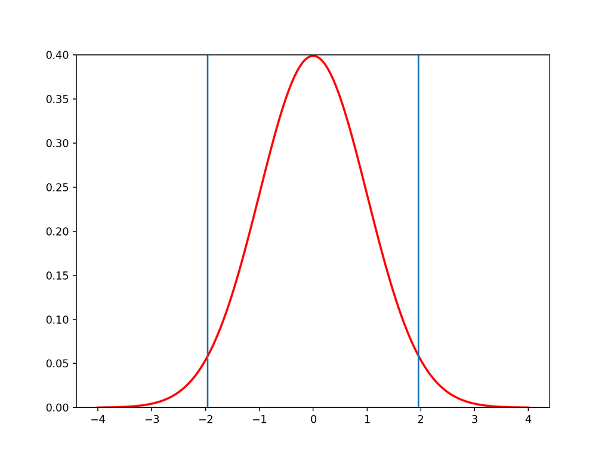

```python
def view_crit_region(alpha):
  from scipy import stats
  import matplotlib

  # calculate the pdf over a range of values
  xx = np.arange(-4, +4, 0.001)
  yy = stats.norm.pdf(xx)

  plt.plot(xx, yy, 'r', lw=2)
  plt.axvline(x = stats.norm.ppf(alpha / 2, loc = 0, scale = 1))
  plt.axvline(x = stats.norm.ppf(1-alpha / 2, loc = 0, scale = 1))
  plt.ylim(0,0.4)
  plt.show()

view_crit_region(0.05)
```

## Relation to Confidence Intervals

- It is interesting to examine the above acceptance region. Here, we accept $H_0$ if

$$\left|\frac{\overline{X}-\mu_0}{\sigma / \sqrt{n}} \right| \leq z_{\frac{\alpha}{2}}.$$

- We can rewrite the above condition as

$$\mu_0 \in \left[\overline{X}- z_{\frac{\alpha}{2}} \frac{\sigma}{\sqrt{n}} , \overline{X}+ z_{\frac{\alpha}{2}} \frac{\sigma}{\sqrt{n}}\right].$$

- The above interval is the $(1−\alpha)100\%$ confidence interval for $\mu_0$
- This is not a coincidence as there is a general relationship between confidence interval problems and hypothesis testing problems

# Hypothesis testing summary

## Test statistics and acceptance regions for a two-sided test of the mean

Two-sided hypothesis test for the mean $H_0: \mu=\mu_0, H_1: \mu\ne\mu_0$

| Case | Test Statistic | Acceptance Region |
| --- | --- | --- |
| $X_i \sim N(\mu, \sigma^2),\;\sigma$ known | $W=\frac{\overline{X}-\mu_0}{\sigma / \sqrt{n}}$ | $\vert W \vert \leq -z_{\frac{\alpha}{2}}$ |
| $n$ large, $X_i$ non-normal | $W=\frac{\overline{X}-\mu_0}{S / \sqrt{n}}$ | $\vert W \vert \leq -z_{\frac{\alpha}{2}}$ |
| $X_i \sim N(\mu, \sigma^2),\;\sigma$ unknown | $W=\frac{\overline{X}-\mu_0}{S / \sqrt{n}}$ | $\vert W \vert \leq -t_{\frac{\alpha}{2},n-1}$ |

## Test statistics and acceptance regions for a one-sided test of the mean

One-sided hypothesis test for the mean $H_0: \mu\leq\mu_0, H_1: \mu\gt\mu_0$

| Case | Test Statistic | Acceptance Region |
| --- | --- | --- |
| $X_i \sim N(\mu, \sigma^2),\;\sigma$ known | $W=\frac{\overline{X}-\mu_0}{\sigma / \sqrt{n}}$ | $W \leq -z_{\alpha}$ |
| $n$ large, $X_i$ non-normal | $W=\frac{\overline{X}-\mu_0}{S / \sqrt{n}}$ | $W \leq -z_{\alpha}$ |
| $X_i \sim N(\mu, \sigma^2),\;\sigma$ unknown | $W=\frac{\overline{X}-\mu_0}{S / \sqrt{n}}$ | $W \leq -t_{\alpha,n-1}$ |

[output not shown]

we can again repeat the above analysis and we obtain the acceptance regions reflected in the table below

| Case | Test Statistic | Acceptance Region |
| --- | --- | --- |
| $X_i \sim N(\mu, \sigma^2),\;\sigma$ known | $W=\frac{\overline{X}-\mu_0}{\sigma / \sqrt{n}}$ | $W \geq -z_{\alpha}$ |
| $n$ large, $X_i$ non-normal | $W=\frac{\overline{X}-\mu_0}{S / \sqrt{n}}$ | $W \geq -z_{\alpha}$ |
| $X_i \sim N(\mu, \sigma^2),\;\sigma$ unknown | $W=\frac{\overline{X}-\mu_0}{S / \sqrt{n}}$ | $W \geq -t_{\alpha,n-1}$ |